# PalaeoOpen Vegan exercise

Author

Gavin L. Simpson

Load some packages

```r
library("here")
## here() starts at /Users/gavin/work/projects/EU/palaeopen/meetings/sofia-2026/teaching
library("analogue")
## Loading required package: vegan
## Loading required package: permute
## analogue version 0.18.1
library("vegan")
library("ggvegan")
library("cepreader")
```

If any of these do not load without error, install the package and try again.

Here we create a plot of the Abernethy Forest data

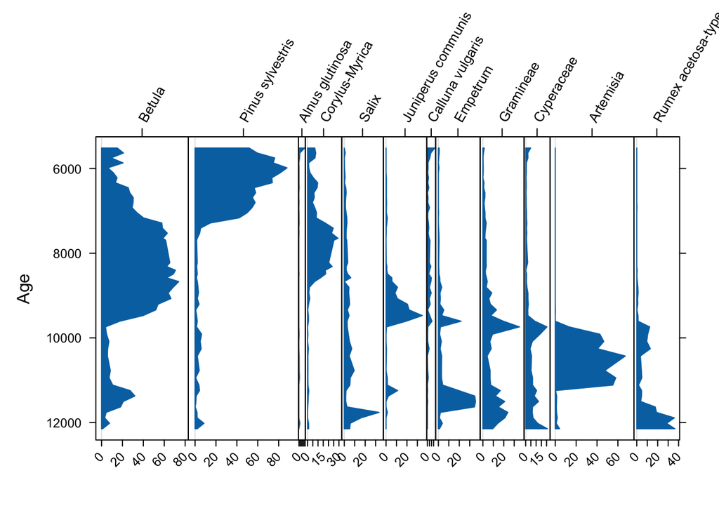

```r
data(abernethy)
Stratiplot(Age ~ . - Depth,
           data = chooseTaxa(abernethy, n.occ = 3, max.abun = 5),
           type = "poly")
```

Subset the data to just the species counts

```r
aber <- abernethy[, 1:36]
```

Fit a PCA

```r
aber_pca <- pca(decostand(aber, method = "hellinger"))
```

and plot it:

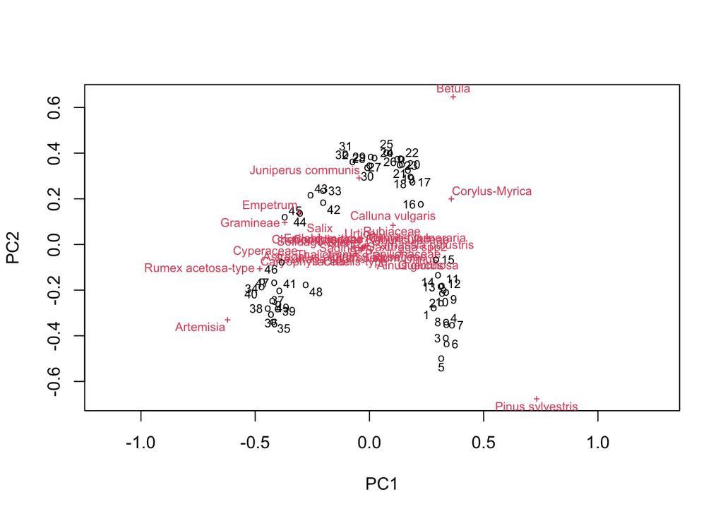

```r
ordipointlabel(aber_pca)
```

Now fit a CA

```r
aber_ca <- ca(decostand(aber, method = "total"))
```

and plot it

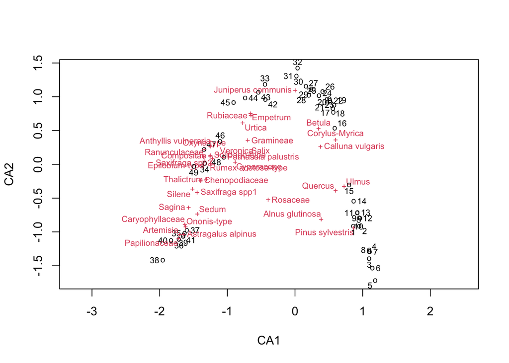

```r
ordipointlabel(aber_ca)
```

How many axes should we consider? Plot a screeplot of $\lambda$ and decide

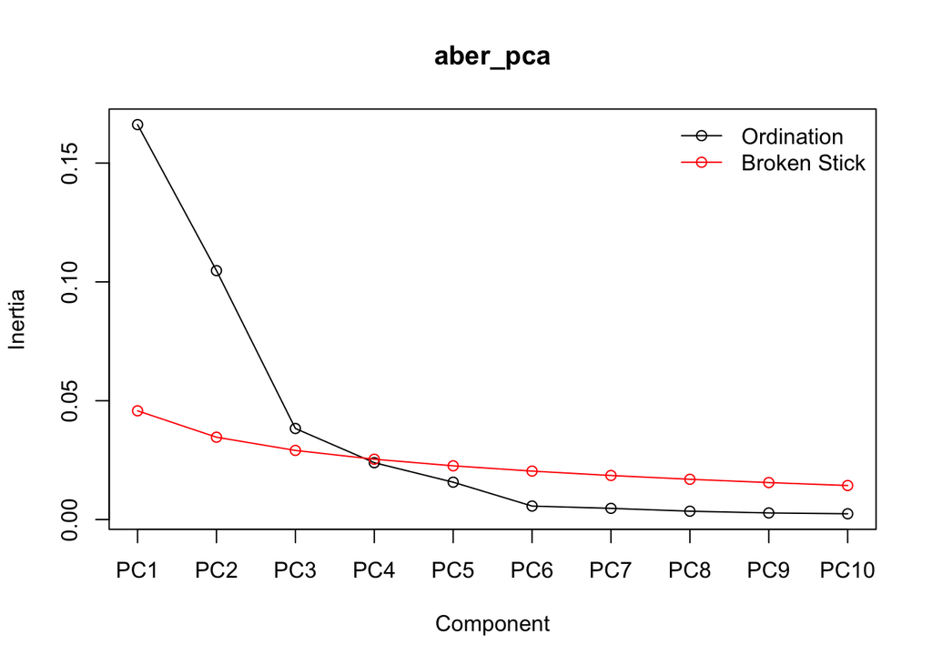

```r
screeplot(aber_pca, type = "l", bstick = TRUE)
```

How many axes should we consider for the CA? Plot a screeplot of $\lambda$ and decide

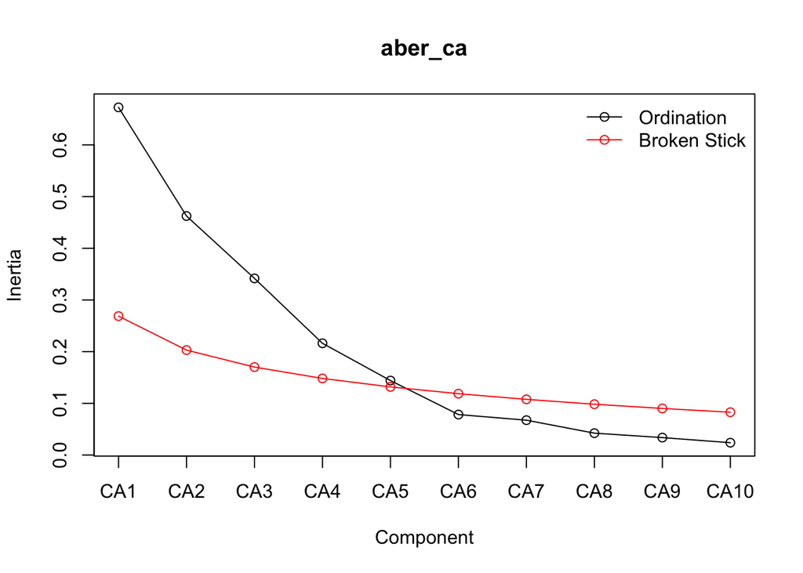

```r
screeplot(aber_ca, type = "l", bstick = TRUE)
```

Sometimes we want to extract and plot the axis scores. Here we do this for the PCA axis 1 scores

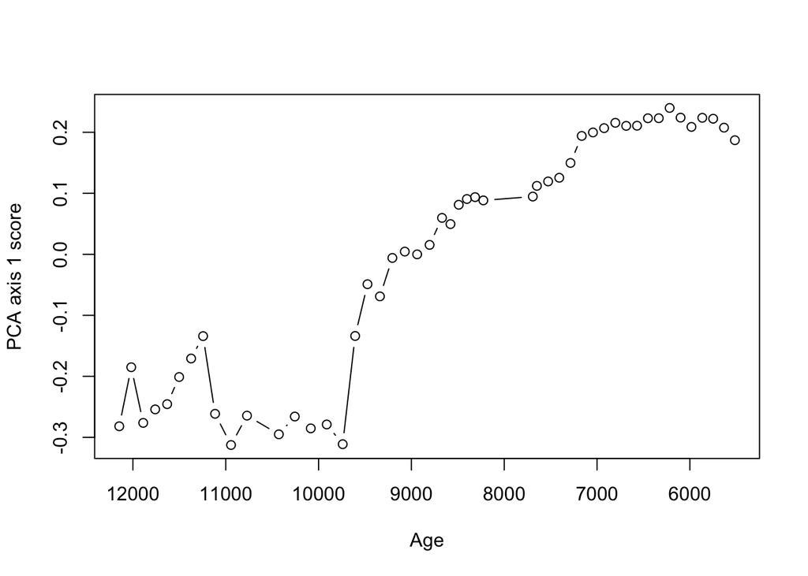

```r
plot(
  abernethy$Age,
  scores(aber_pca, choices = 1, display = "sites", scaling = "sites")[,1],
  type = "b", xlim = rev(range(abernethy$Age)), ylab = "PCA axis 1 score", xlab = "Age"
)
```

And here for the CA axis 2 scores

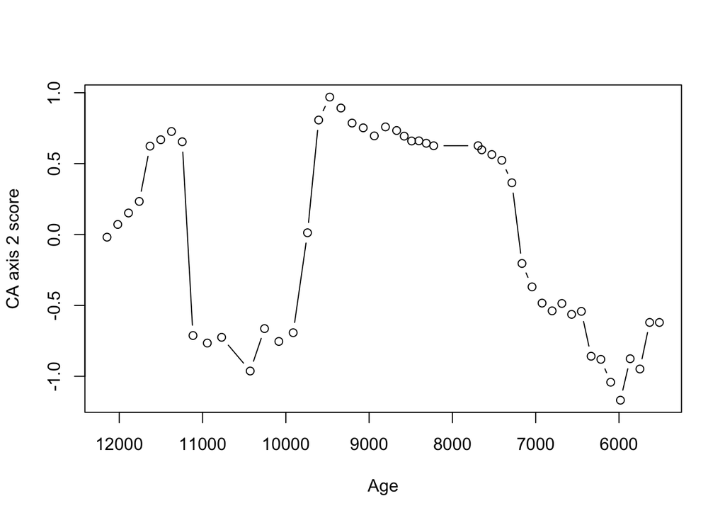

```r
plot(
  abernethy$Age,
  scores(aber_ca, choices = 2, display = "sites", scaling = "sites")[,1],
  type = "b", xlim = rev(range(abernethy$Age)), ylab = "CA axis 2 score",
  xlab = "Age"
)
```

In this part fo the exercise, we will fit a CCA to the SWAP diatom training set using a suite of the chemistry variables as predictors. We will then superimpose a core data set from the RLGH on to the CCA of the training data.

Begin by loading the data:

```r
swap138 <- vegan::read.cep(here("00-data/swap138.cep"))
swap138 <- chooseTaxa(swap138, max.abun = 2)
```

If reading this file fails, you can read the data from the `swapdiat.csv` file in `00-date` using

```r
swap138 <- readr::read_csv(here("00-data/swapdiat.csv"))
## Rows: 138 Columns: 276
## ── Column specification ────────────────────────────────────────────────────────
## Delimiter: ","
## dbl (276): AC001A, AC002A, AC004A, AC013A, AC014A, AC014B, AC014C, AC017A, A...
##
## ℹ Use `spec()` to retrieve the full column specification for this data.
## ℹ Specify the column types or set `show_col_types = FALSE` to quiet this message.
swap138 <- chooseTaxa(swap138 |> as.data.frame(), max.abun = 2)
```

Now we load the water chemistry data:

```r
swapenv <- cepreader::readCEP(here("00-data/swap138.log"))
```

If the last command fails, we can read in the data using `readr::read_csv()`. Asusmign you put the downloaded CSV file in the `00-data` folder, we can read the data as follows:

```r
swapenv <- readr::read_csv(here("00-data/swapenv.csv"))
## Rows: 138 Columns: 10
## ── Column specification ────────────────────────────────────────────────────────
## Delimiter: ","
## dbl (10): pH, Cond, TOC, Ca, Mg, K, SO4, Cl, Equal, Altot
##
## ℹ Use `spec()` to retrieve the full column specification for this data.
## ℹ Specify the column types or set `show_col_types = FALSE` to quiet this message.
```

Now fit the CCA with selected chemistry variables

```r
mod <- cca(swap138 ~ Altot + Cl + TOC + SO4 + Cond + Mg + K + Ca + Equal + pH,
           data = swapenv)
```

Produce plots of the ordination with species and sites separately. First for the samples

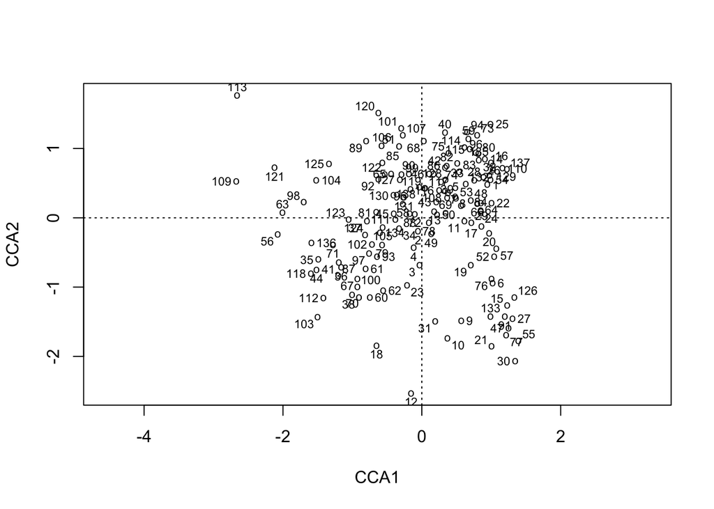

```r
plot(mod, display = c("sites", "bp"), scaling = "symmetric", type = "n")
ordipointlabel(mod, display = c("sites"), scaling = "symmetric", add = TRUE,
               cex = c(0.7,0.7))
```

And now for the species

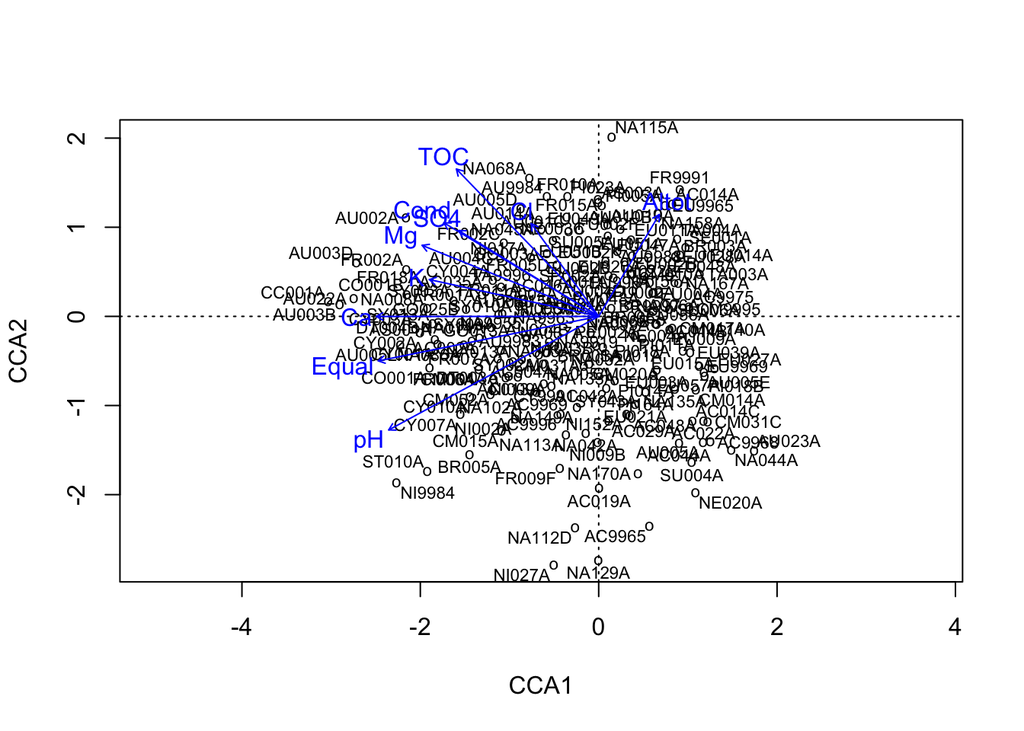

```r
plot(mod, display = c("species", "bp"), scaling = "symmetric", type = "n")
ordipointlabel(mod, display = c("species"), scaling = "symmetric", add = TRUE,
               cex = c(0.7,0.7))
text(mod, display = "bp", col = "blue")
```

Now we can load the RLGH core data and fit the timetrack ordination

```r
data(rlgh)
mod2 <- timetrack(
  swap138, rlgh,
  env = swapenv,
  method = "cca",
  formula = ~ Altot + Cl + TOC + SO4 + Cond + Mg + K + Ca + Equal + pH
)
```

And the we can plot the timetrack:

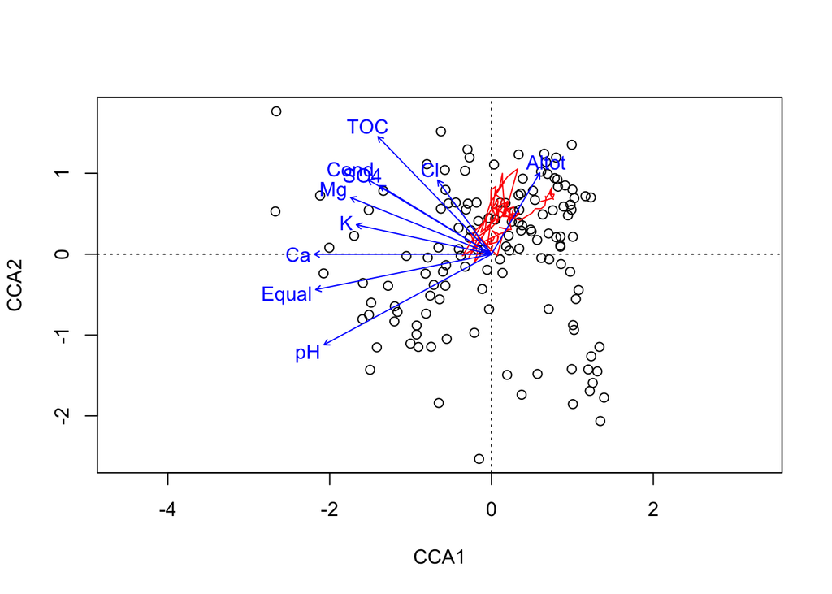

```r
plot(mod2)
text(mod2$ordination, display = "bp", col = "blue")
```